# Aspen Exudates: Exploratory Data Analysis

KW Taylor for Dr. J Karst

# 1 R Package Dependencies

```r
# Dependencies ------------------------------------------------------------
library(tidyverse)
library(readr)
library(modelr)
library(lubridate)
library(GGally)
# Data Import -------------------------------------------------------------
# readR import of aspen_root_exudates_data_v03-02.csv
# readR import of aspen_root_exudates_data_contols.csv
```

# 2 Data Import into R

Data import in to R with readR package. Tidydata cleaning completed previously in Excel.

```r
samples <- read_csv("aspen_root_exudates_data_v03-02.csv")
controls <- read_csv("aspen_root_exudates_data_contols.csv")
```

Inspect data:

```r
controls
```

```
## # A tibble: 16 × 7
##    control_id raw_id   date_id  year month control_flush_vol control_carbon_conc
##    <chr>      <chr>      <dbl> <dbl> <dbl>             <dbl>               <dbl>
##  1 C012       Control…  202105  2021     5            0.04                  3.82
##  2 C015       Control…  202107  2021     7            0.033                 4.33
##  3 C013       Control…  202105  2021     5            0.035                 4.47
##  4 C001       Control   201910  2019    10            0.034                 4.59
##  5 C008       Control…  202007  2020     7            0.0385                4.71
##  6 C007       Control…  202007  2020     7            0.0305                5.22
##  7 C006       Control…  202007  2020     7            0.029                 5.31
##  8 C009       Control…  202009  2020     9            0.028                 5.79
##  9 C010       Control…  202009  2020     9            0.03                  5.95
## 10 C011       Control…  202009  2020     9            0.031                 5.96
## 11 C005       Control…  202005  2020     5            0.027                 6.12
## 12 C003       Control…  202005  2020     5            0.033                 6.18
## 13 C002       Control…  202005  2020     5            0.03                  6.18
## 14 C004       Control…  202005  2020     5            0.029                 6.21
## 15 C016       Control…  202107  2021     7            0.032                 7.27
## 16 C014       Control…  202107  2021     7            0.035                 7.71
```

```r
samples
```

```
## # A tibble: 60 × 31
##    sample_id cuvette_id date_id  year month fructose arabitol glucose mannitol
##    <chr>          <dbl>   <dbl> <dbl> <dbl>    <dbl>    <dbl>   <dbl>    <dbl>
##  1 S001               1  201910  2019    10    0       0.221    0.239    0
##  2 S002               2  201910  2019    10    0       0        0.133    0.398
##  3 S003               3  201910  2019    10    0       0        0        0
##  4 S004               4  201910  2019    10   NA      NA       NA       NA
##  5 S005               5  201910  2019    10    0       0.483    0        1.14
##  6 S006               6  201910  2019    10    0.329   0.416    0.935    0
##  7 S007               7  201910  2019    10   NA      NA       NA       NA
##  8 S008               8  201910  2019    10    0.133   0        0.234    0
##  9 S009               9  201910  2019    10    0       0.0651   0.141    0
## 10 S010              10  201910  2019    10    0       0        0        0.797
## # ℹ 50 more rows
## # ℹ 22 more variables: sucrose <dbl>, trehalose <dbl>, starch <dbl>,
## #   glycogen <dbl>, sample_flush_vol <dbl>, fine_root_mass <dbl>,
## #   root_area_0_1 <dbl>, root_area_1_2 <dbl>, root_area_2 <dbl>,
## #   root_length_0_1 <dbl>, root_length_1_2 <dbl>, root_length_2 <dbl>,
## #   root_examined <dbl>, long <dbl>, contact <dbl>,
## #   long_to_contact_ratio <dbl>, uncolonized <dbl>, …
```

```r
samples <- samples %>%
  mutate("date" = ym(date_id)) %>%
  relocate(date, .before = date_id)
```

```r
typeof(samples$date)
```

```
## [1] "double"
```

# 3 Preliminary Transformation

## 3.1 Normalizing Sugar Variables with a min_max ranging function

Normalizing by ranging between min and max for each sugar, specifically $Y' = \frac{Y - Y_{min}}{Y_{max} - Y_{min}}$. All transformed values will be $\mathbb{R}\in [0, 1]$. This helps with visual comparisons as all ranges can by portrayed on the same scale but has limited effect on the distribution

The min-max normalizing function is defined:

```r
# Min-Max Normalize Function
# v 0.1
min_max_norm <- function(x) {
  (x - min(x, na.rm = TRUE)) / (max(x, na.rm = TRUE) - min(x, na.rm = TRUE))
}
```

Apply the min-max normalization transformation to the sugar column values:

```r
# normalize samples table
samples_norm_mm <- samples %>%
  mutate(across(fructose:glycogen, .fns = min_max_norm, .names = "{.col}_norm_mm")) %>%
  select(-fructose:-sample_flush_vol,-year,-month) %>%
  relocate(fructose_norm_mm:glycogen_norm_mm, .before = fine_root_mass)
samples_norm_mm
```

```
## # A tibble: 60 × 29
##    sample_id cuvette_id date       date_id fructose_norm_mm arabitol_norm_mm
##    <chr>          <dbl> <date>       <dbl>            <dbl>            <dbl>
##  1 S001               1 2019-10-01  201910           0                0.0648
##  2 S002               2 2019-10-01  201910           0                0
##  3 S003               3 2019-10-01  201910           0                0
##  4 S004               4 2019-10-01  201910          NA               NA
##  5 S005               5 2019-10-01  201910           0                0.142
##  6 S006               6 2019-10-01  201910           0.164            0.122
##  7 S007               7 2019-10-01  201910          NA               NA
##  8 S008               8 2019-10-01  201910           0.0663           0
##  9 S009               9 2019-10-01  201910           0                0.0191
## 10 S010              10 2019-10-01  201910           0                0
## # ℹ 50 more rows
## # ℹ 23 more variables: glucose_norm_mm <dbl>, mannitol_norm_mm <dbl>,
## #   sucrose_norm_mm <dbl>, trehalose_norm_mm <dbl>, starch_norm_mm <dbl>,
## #   glycogen_norm_mm <dbl>, fine_root_mass <dbl>, root_area_0_1 <dbl>,
## #   root_area_1_2 <dbl>, root_area_2 <dbl>, root_length_0_1 <dbl>,
## #   root_length_1_2 <dbl>, root_length_2 <dbl>, root_examined <dbl>,
## #   long <dbl>, contact <dbl>, long_to_contact_ratio <dbl>, …
```

# 4 Initial Exporatory Data Analysis

## 4.1 Pivot Sugar Columns into One Column to Allow Faceting

By combining all sugar observations into one column, faceting by sugar type will be simpler for exploration. Summary statistics cannot be performed on any of the non-sugar columns in *pivot_samples* but will still be useful for EDA.

```r
pivot_samples_norm_mm <- samples_norm_mm %>%
  pivot_longer(fructose_norm_mm:glycogen_norm_mm, names_to = "sugar_type", values_to = "sugar_conc")
pivot_samples_norm_mm
```

```
## # A tibble: 480 × 23
##    sample_id cuvette_id date       date_id fine_root_mass root_area_0_1
##    <chr>          <dbl> <date>       <dbl>          <dbl>         <dbl>
##  1 S001               1 2019-10-01  201910           24.4          10.6
##  2 S001               1 2019-10-01  201910           24.4          10.6
##  3 S001               1 2019-10-01  201910           24.4          10.6
##  4 S001               1 2019-10-01  201910           24.4          10.6
##  5 S001               1 2019-10-01  201910           24.4          10.6
##  6 S001               1 2019-10-01  201910           24.4          10.6
##  7 S001               1 2019-10-01  201910           24.4          10.6
##  8 S001               1 2019-10-01  201910           24.4          10.6
##  9 S002               2 2019-10-01  201910           38.4          14.7
## 10 S002               2 2019-10-01  201910           38.4          14.7
## # ℹ 470 more rows
## # ℹ 17 more variables: root_area_1_2 <dbl>, root_area_2 <dbl>,
## #   root_length_0_1 <dbl>, root_length_1_2 <dbl>, root_length_2 <dbl>,
## #   root_examined <dbl>, long <dbl>, contact <dbl>,
## #   long_to_contact_ratio <dbl>, uncolonized <dbl>, colonized_root_tips <dbl>,
## #   total_root_tips <dbl>, root_tip_density <dbl>, percent_colonization <dbl>,
## #   c_conc <dbl>, sugar_type <chr>, sugar_conc <dbl>
```

## 4.2 Faceting by Sugar Type

First, creating a faceting function for our purposes to reduce duplication:

```r
# Facet by Sugars Function
facet_by_sugars <- function (input) {
  ggplot(data = pivot_samples_norm_mm,
         aes_string(x = {input}, y = "sugar_conc", colour = "sugar_type")) +
    geom_point(alpha = 1/2) +
    facet_wrap(vars(sugar_type), ncol = 4) +
    theme(legend.position = "bottom",
          legend.text = element_text(size = 8))
}
```

### 4.2.1 Percent Colonization

Plot percent colonization versus normalized sugar concentration, facet by sugar type

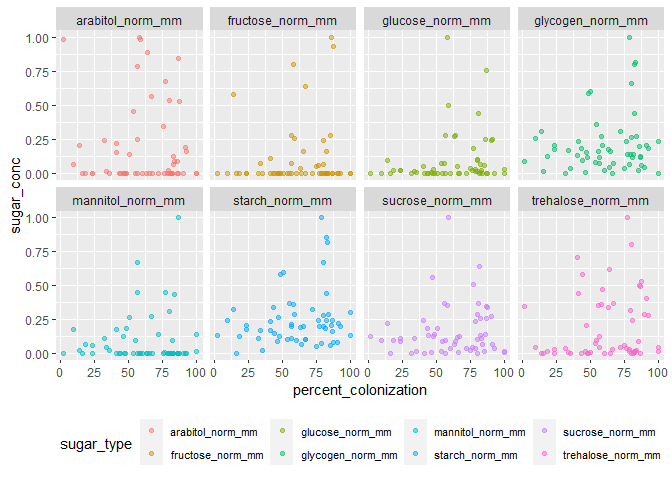

```r
facet_by_sugars("percent_colonization")
```

### Root_area_0_1

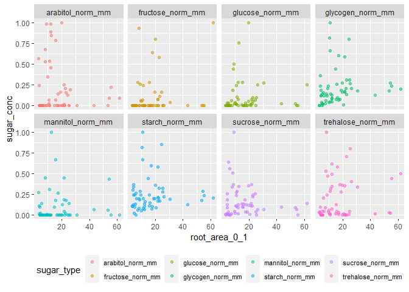

```r
facet_by_sugars("root_area_0_1")
```

### Long to Contact Ratio

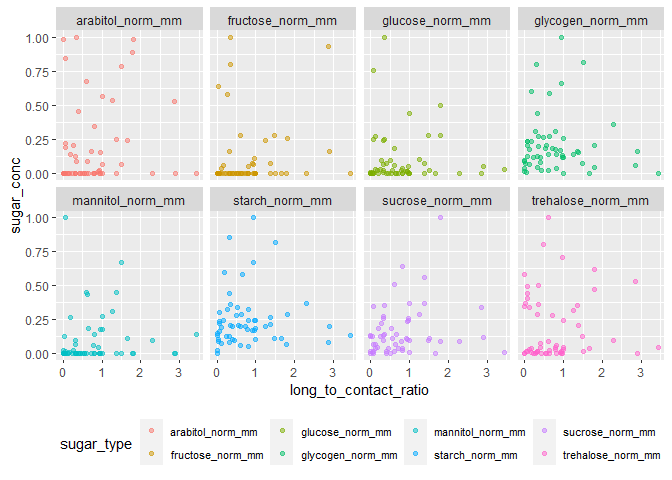

```r
facet_by_sugars("long_to_contact_ratio")
```

### 4.2.2 Root Tip Density

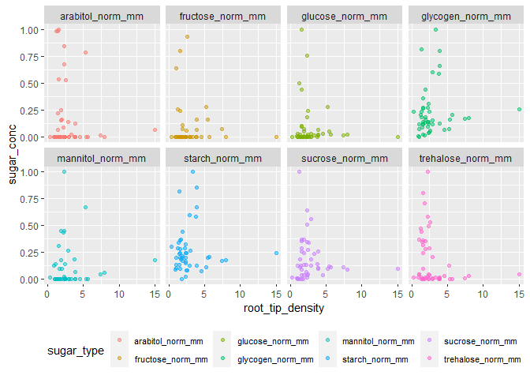

```r
facet_by_sugars("root_tip_density")
```

### 4.2.3 Total Root Tips

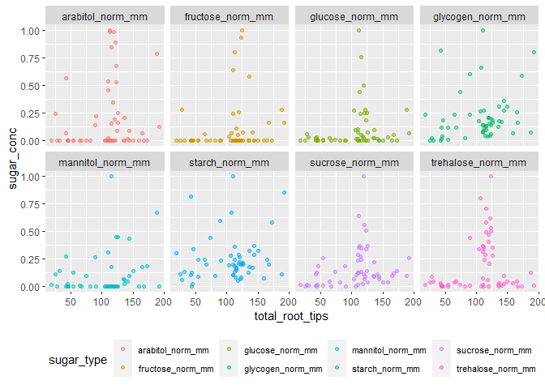

```r
facet_by_sugars("total_root_tips")
```

## 4.3 Glycogen vs Starch

Remarkably similar distributions in glycogen and starch for all facets. Given this pattern is persisting regardless of faceting variable, this suggest they may be related to each other independent of input variable

#### 4.3.0.1 Comparison of glycogen vs starch

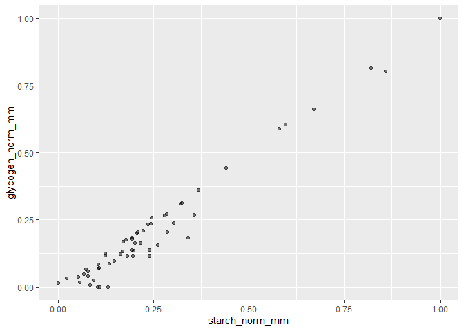

```r
samples_norm_mm %>%
  ggplot(aes(x = starch_norm_mm, y = glycogen_norm_mm)) +
    geom_point(alpha = 1/2)
```

This is interesting. Clear linear relationship. Is it possible this is an artifact of the analytics machine?

### 4.3.1 Linear Model

Fit data to a linear model x = starch, y = glycogen. Directionality chosen based off energy flow diagram.

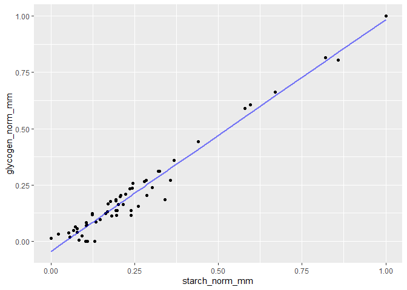

```r
# set model
mod_starch_glycogen <- lm(glycogen_norm_mm ~ starch_norm_mm, data = samples_norm_mm)

# model predictions
grid <- samples_norm_mm %>%
  data_grid(starch_norm_mm) %>%
  add_predictions(mod_starch_glycogen)
# graph predication
ggplot(samples_norm_mm, aes(x = starch_norm_mm)) +
  geom_point(aes(y = glycogen_norm_mm)) +
  geom_line(aes(y = pred), data = grid, colour = "blue", size = 1, alpha = 1/2)
```

Pretty good fit. What are the residuals?

```r
lm_glycogen_starch <- samples_norm_mm %>%
  add_residuals(mod_starch_glycogen) %>%
  select(date, starch_norm_mm, glycogen_norm_mm, resid)
lm_glycogen_starch
```

```
## # A tibble: 60 × 4
##    date       starch_norm_mm glycogen_norm_mm   resid
##    <date>              <dbl>            <dbl>   <dbl>
##  1 2019-10-01          0.820           0.816   0.0164
##  2 2019-10-01          0.439           0.443   0.0356
##  3 2019-10-01          0               0.0134  0.0583
##  4 2019-10-01         NA              NA      NA
##  5 2019-10-01          0.596           0.606   0.0363
##  6 2019-10-01          0.857           0.803  -0.0349
##  7 2019-10-01         NA              NA      NA
##  8 2019-10-01          0.671           0.662   0.0157
##  9 2019-10-01          1               1       0.0145
## 10 2019-10-01          0.580           0.590   0.0369
## # ℹ 50 more rows
```

How are the residuals distributed?

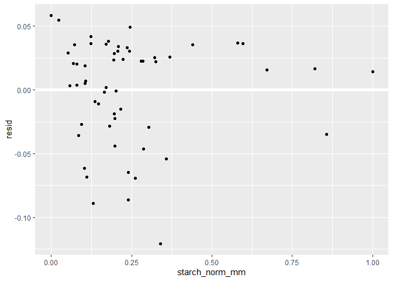

```r
ggplot(lm_glycogen_starch, aes(starch_norm_mm, resid)) +
  geom_ref_line(h = 0) +
  geom_point()
```

#### 4.3.1.1 Comparison of trehalose vs glucose

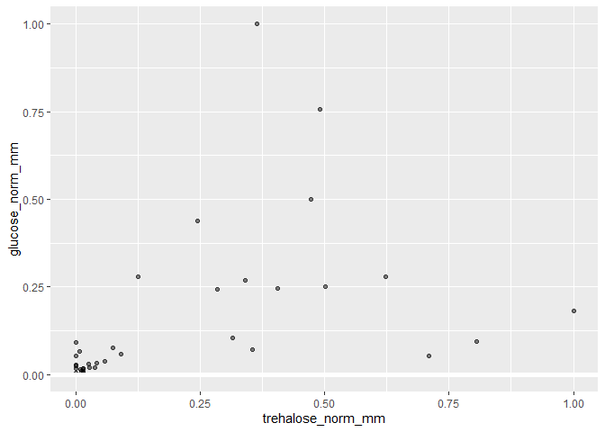

```r
samples_norm_mm %>%
  ggplot(aes(x = trehalose_norm_mm, y = glucose_norm_mm)) +
    geom_point(alpha = 1/2) +
    geom_ref_line(h = 0)
```

This shows no obvious relationship. Try binning the relationshiip by percent colonization:

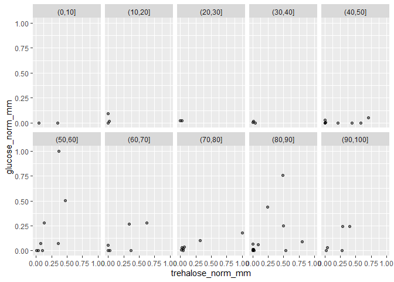

```r
transform(samples_norm_mm, bin_var = cut(percent_colonization, seq(0, 100, 10))) %>%
  ggplot(aes(x = trehalose_norm_mm, y = glucose_norm_mm)) +
    geom_point(alpha = 1/2) +
    facet_wrap(vars(bin_var), ncol=5)
```

## 4.4 Noise effect of tree phenological state

Question: What if a contribution to the noisiness of the data is that that the relationships between fungal and tree sugars are dependent on the phenology of the tree?

#### 4.4.0.1 Plot sugars through time

```r
# group by sugar type
group_by_sugar_type <- group_by(pivot_samples_norm_mm, date, sugar_type)
# create summary table
mean_sugar_by_type <- summarise(group_by_sugar_type, mean_sugar_conc = mean(sugar_conc, na.rm = TRUE))
```

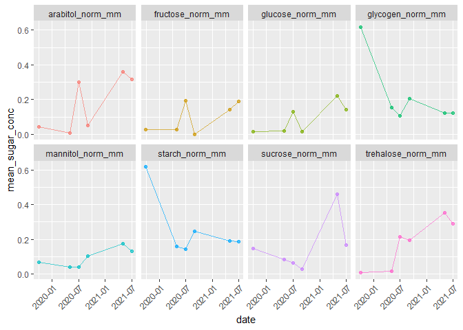

```r
mean_sugar_by_type %>%
  ggplot(aes(x = date, y = mean_sugar_conc, colour = sugar_type)) +
    geom_point(alpha = 2/3) +
    geom_line(alpha = 2/3) +
    facet_wrap(vars(sugar_type), ncol = 4) +
    theme(axis.text.x = element_text(angle = 45, hjust = 1),
          legend.position = "none",
          legend.text = element_text(size = 8))
```

Arabitol, fructose, and glucose appear to co-vary when date is considered. Let’s focus on that.

## 4.5 Covariance in Arabitol, Glucose, and Fructose?

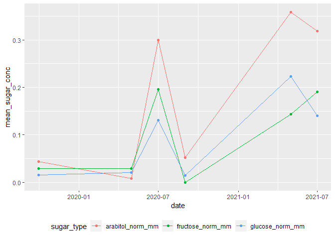

```r
mean_sugar_by_type %>%
  filter(sugar_type %in% c("arabitol_norm_mm","fructose_norm_mm","glucose_norm_mm")) %>%
  ggplot(aes(x = date, y = mean_sugar_conc, colour = sugar_type)) +
    geom_point() +
    geom_line() +
    theme(legend.position = "bottom")
```

Boxplots instead of points ?

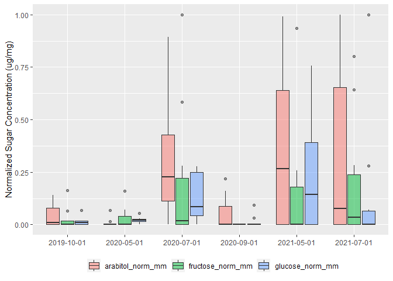

```r
pivot_samples_norm_mm %>%
  filter(sugar_type %in% c("arabitol_norm_mm","fructose_norm_mm", "glucose_norm_mm")) %>%
  ggplot(aes(x = factor(date), y = sugar_conc, fill = sugar_type)) +
    geom_boxplot(alpha = 1/2) +
    theme(legend.title = element_blank(),
          legend.position = "bottom",
          axis.title.x = element_blank()) +
    labs(y="Normalized Sugar Concentration (ug/mg)")
```

```r
pivot_samples_norm_mm %>%
  filter(sugar_type %in% c("arabitol_norm_mm","fructose_norm_mm","glucose_norm_mm"))
```

```
## # A tibble: 180 × 23
##    sample_id cuvette_id date       date_id fine_root_mass root_area_0_1
##    <chr>          <dbl> <date>       <dbl>          <dbl>         <dbl>
##  1 S001               1 2019-10-01  201910           24.4         10.6
##  2 S001               1 2019-10-01  201910           24.4         10.6
##  3 S001               1 2019-10-01  201910           24.4         10.6
##  4 S002               2 2019-10-01  201910           38.4         14.7
##  5 S002               2 2019-10-01  201910           38.4         14.7
##  6 S002               2 2019-10-01  201910           38.4         14.7
##  7 S003               3 2019-10-01  201910           19.5          5.80
##  8 S003               3 2019-10-01  201910           19.5          5.80
##  9 S003               3 2019-10-01  201910           19.5          5.80
## 10 S004               4 2019-10-01  201910           NA            6.64
## # ℹ 170 more rows
## # ℹ 17 more variables: root_area_1_2 <dbl>, root_area_2 <dbl>,
## #   root_length_0_1 <dbl>, root_length_1_2 <dbl>, root_length_2 <dbl>,
## #   root_examined <dbl>, long <dbl>, contact <dbl>,
## #   long_to_contact_ratio <dbl>, uncolonized <dbl>, colonized_root_tips <dbl>,
## #   total_root_tips <dbl>, root_tip_density <dbl>, percent_colonization <dbl>,
## #   c_conc <dbl>, sugar_type <chr>, sugar_conc <dbl>
```

```r
typeof(pivot_samples_norm_mm$date)
```

```
## [1] "double"
```

### 4.5.1 Linear Model: Glucose + Fructose = Arabitol

Fitting this data to a linear model, we have two possible models:

$$\begin{align} Y &= a_0 + a_1X_1 +
a_2X_2 \tag{1},\\\\ Y &= a_0+a_1X_1+a_2X_2+a_{12}X_1X_2 \tag{2}
\end{align}$$

Setting the models:

```r
mod1_arab_fruc_gluc <- lm(arabitol_norm_mm ~ fructose_norm_mm + glucose_norm_mm, data = samples_norm_mm)

mod2_arab_fruc_gluc <- lm(arabitol_norm_mm ~ fructose_norm_mm * glucose_norm_mm, data = samples_norm_mm)
```

Producing a Data Grid for Visualizing the Model Predictions

```r
grid <- samples_norm_mm %>%
  data_grid(fructose_norm_mm,glucose_norm_mm) %>%
  gather_predictions(mod1_arab_fruc_gluc, mod2_arab_fruc_gluc)
grid
```

```
## # A tibble: 1,480 × 4
##    model               fructose_norm_mm glucose_norm_mm   pred
##    <chr>                          <dbl>           <dbl>  <dbl>
##  1 mod1_arab_fruc_gluc                0         0       0.0888
##  2 mod1_arab_fruc_gluc                0         0.00391 0.0924
##  3 mod1_arab_fruc_gluc                0         0.00428 0.0927
##  4 mod1_arab_fruc_gluc                0         0.00953 0.0976
##  5 mod1_arab_fruc_gluc                0         0.0101  0.0981
##  6 mod1_arab_fruc_gluc                0         0.0133  0.101
##  7 mod1_arab_fruc_gluc                0         0.0167  0.104
##  8 mod1_arab_fruc_gluc                0         0.0171  0.105
##  9 mod1_arab_fruc_gluc                0         0.0176  0.105
## 10 mod1_arab_fruc_gluc                0         0.0196  0.107
## # ℹ 1,470 more rows
```

Adding the residuals:

```r
grid1 <- samples_norm_mm %>%
  gather_residuals(mod1_arab_fruc_gluc, mod2_arab_fruc_gluc) %>%
  select(model, date, fructose_norm_mm, glucose_norm_mm, arabitol_norm_mm, resid)
grid1
```

```
## # A tibble: 120 × 6
##    model    date       fructose_norm_mm glucose_norm_mm arabitol_norm_mm   resid
##    <chr>    <date>                <dbl>           <dbl>            <dbl>   <dbl>
##  1 mod1_ar… 2019-10-01           0              0.0171            0.0648 -0.0397
##  2 mod1_ar… 2019-10-01           0              0.00953           0      -0.0976
##  3 mod1_ar… 2019-10-01           0              0                 0      -0.0888
##  4 mod1_ar… 2019-10-01          NA             NA                NA      NA
##  5 mod1_ar… 2019-10-01           0              0                 0.142   0.0528
##  6 mod1_ar… 2019-10-01           0.164          0.0668            0.122  -0.0458
##  7 mod1_ar… 2019-10-01          NA             NA                NA      NA
##  8 mod1_ar… 2019-10-01           0.0663         0.0167            0      -0.111
##  9 mod1_ar… 2019-10-01           0              0.0101            0.0191 -0.0790
## 10 mod1_ar… 2019-10-01           0              0                 0      -0.0888
## # ℹ 110 more rows
```

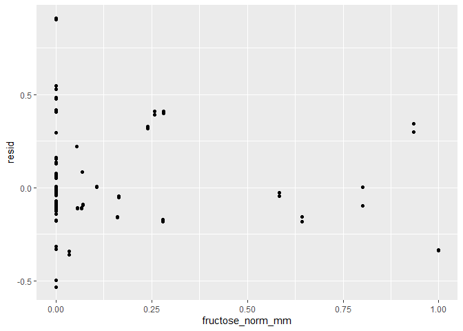

```r
grid1 %>%
  ggplot(aes(fructose_norm_mm, resid)) +
    geom_point()
```

Visualizing the Models (INCOMPLETE):

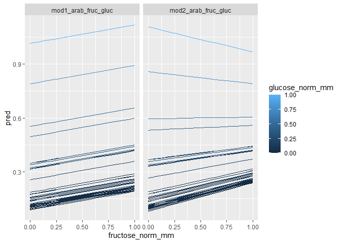

```r
ggplot(grid, aes(fructose_norm_mm, pred, colour = glucose_norm_mm, group = glucose_norm_mm)) +
  geom_line() +
  facet_wrap(~model)
```

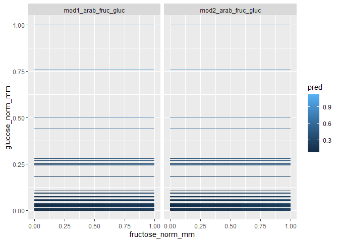

```r
ggplot(grid, aes(fructose_norm_mm, glucose_norm_mm, colour = pred, group = glucose_norm_mm)) +
  geom_line() +
  facet_wrap(~model)
```

#### 4.5.1.1 Fructose vs Glucose

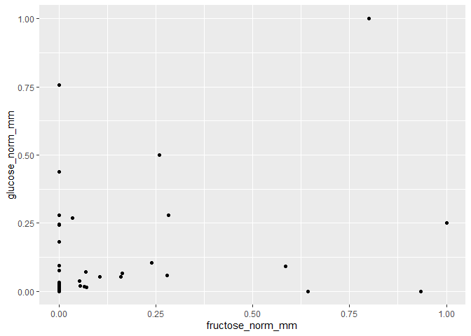

```r
ggplot(data = samples_norm_mm, aes(x = fructose_norm_mm, y = glucose_norm_mm)) +
  geom_point()
```

#### 4.5.1.2 Pairwise Correlation Testing

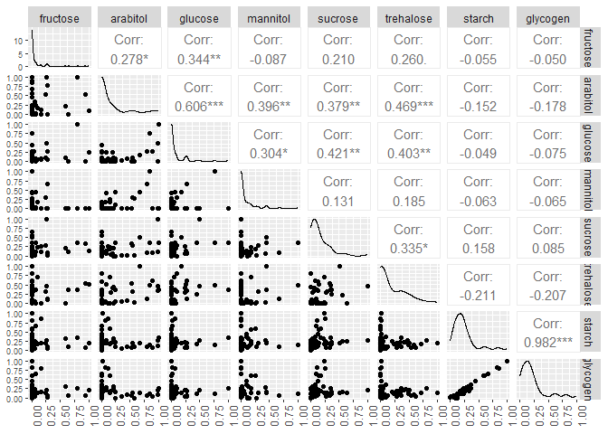

```r
samples_sugars_select <- samples_norm_mm %>%
  select(fructose_norm_mm:glycogen_norm_mm)
samples_sugars_select_rm_na <- samples_sugars_select %>%
  na.omit()
#rename the columns for better graphing
#names(samples_sugars_select_rm_na) <- map(names, ~ substr(.x,1, nchar(.x)-8))
#names(samples_sugars_select_rm_na)
#graph
output <- samples_sugars_select_rm_na %>%
  rename_with(~ substr(.x, 1, nchar(.x) - 8)) %>%
  ggpairs(progress = FALSE, size = 0.5) +
  theme(axis.text.x = element_text(angle = 90, hjust = 1),
        axis.text.y = element_text(size = 7, hjust = 1))
print(output)
```

According to this pairwise test, the highest correlation (excluding starch vs glycogen which has already been explored) is arabitol vs glucose:

#### 4.5.1.3 Glucose vs. Arabitol

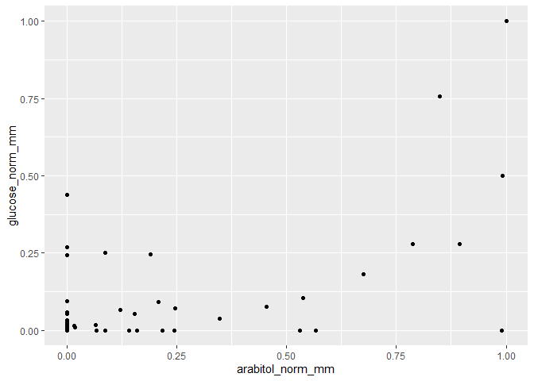

```r
samples_sugars_select_rm_na %>%
  ggplot(aes(y = glucose_norm_mm, x = arabitol_norm_mm)) +
  geom_point()
```

```r
glucose_arabitol_lm <- lm(arabitol_norm_mm ~ glucose_norm_mm, data = samples_sugars_select_rm_na)
summary(glucose_arabitol_lm)
```

```
##
## Call:
## lm(formula = arabitol_norm_mm ~ glucose_norm_mm, data = samples_sugars_select_rm_na)
##
## Residuals:
##      Min       1Q   Median       3Q      Max
## -0.52111 -0.11217 -0.09509  0.04648  0.89533
##
## Coefficients:
##                 Estimate Std. Error t value Pr(>|t|)
## (Intercept)      0.09509    0.03607   2.636   0.0109 *
## glucose_norm_mm  0.97013    0.17160   5.654  5.8e-07 ***
## ---
## Signif. codes:  0 '***' 0.001 '**' 0.01 '*' 0.05 '.' 0.1 ' ' 1
##
## Residual standard error: 0.2432 on 55 degrees of freedom
## Multiple R-squared:  0.3675, Adjusted R-squared:  0.356
## F-statistic: 31.96 on 1 and 55 DF,  p-value: 5.796e-07
```

```r
summary(select(samples_sugars_select_rm_na,arabitol_norm_mm,glucose_norm_mm))
```

```
##  arabitol_norm_mm glucose_norm_mm
##  Min.   :0.0000   Min.   :0.00000
##  1st Qu.:0.0000   1st Qu.:0.00000
##  Median :0.0000   Median :0.01707
##  Mean   :0.1868   Mean   :0.09458
##  3rd Qu.:0.2174   3rd Qu.:0.07538
##  Max.   :1.0000   Max.   :1.00000
```

#### 4.5.1.4 Exponent Model

```r
glucose_arabitol_exp_mod <- lm(arabitol_norm_mm ~ log(glucose_norm_mm+0.375), data = samples_sugars_select_rm_na)
summary(glucose_arabitol_exp_mod)
```

```
##
## Call:
## lm(formula = arabitol_norm_mm ~ log(glucose_norm_mm + 0.375),
##     data = samples_sugars_select_rm_na)
##
## Residuals:
##      Min       1Q   Median       3Q      Max
## -0.56494 -0.10613 -0.07727  0.07723  0.91315
##
## Coefficients:
##                              Estimate Std. Error t value Pr(>|t|)
## (Intercept)                   0.69429    0.09681   7.172 1.97e-09 ***
## log(glucose_norm_mm + 0.375)  0.62908    0.11308   5.563 8.08e-07 ***
## ---
## Signif. codes:  0 '***' 0.001 '**' 0.01 '*' 0.05 '.' 0.1 ' ' 1
##
## Residual standard error: 0.2447 on 55 degrees of freedom
## Multiple R-squared:  0.3601, Adjusted R-squared:  0.3484
## F-statistic: 30.95 on 1 and 55 DF,  p-value: 8.085e-07
```

```r
samples_sugars_select_rm_na$pred_exp = predict(glucose_arabitol_exp_mod)
samples_sugars_select_rm_na
```

```
## # A tibble: 57 × 9
##    fructose_norm_mm arabitol_norm_mm glucose_norm_mm mannitol_norm_mm
##               <dbl>            <dbl>           <dbl>            <dbl>
##  1           0                0.0648         0.0171            0
##  2           0                0              0.00953           0.0919
##  3           0                0              0                 0
##  4           0                0.142          0                 0.264
##  5           0.164            0.122          0.0668            0
##  6           0.0663           0              0.0167            0
##  7           0                0.0191         0.0101            0
##  8           0                0              0                 0.184
##  9           0.160            0              0.0529            0
## 10           0                0              0.0176            0.0669
## # ℹ 47 more rows
## # ℹ 5 more variables: sucrose_norm_mm <dbl>, trehalose_norm_mm <dbl>,
## #   starch_norm_mm <dbl>, glycogen_norm_mm <dbl>, pred_exp <dbl>
```

Graphing

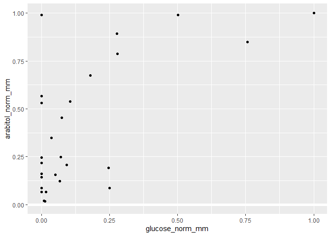

```r
samples_sugars_select_rm_na %>%
  ggplot(aes(glucose_norm_mm, arabitol_norm_mm)) +
  geom_point() +
  geom_ref_line(h = 0) +
  geom_smooth(method = "log")
```

```r
  #geom_smooth(method = "lm")
```

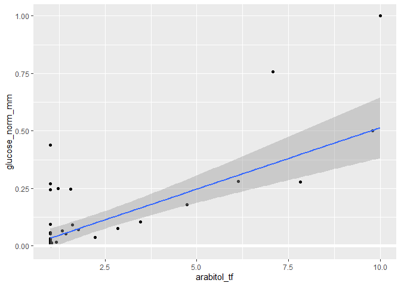

```r
glucose_arabitol <- samples_sugars_select_rm_na %>%
  select(glucose_norm_mm, arabitol_norm_mm)
glucose_log_1_arabitol <- glucose_arabitol %>%
  mutate("arabitol_tf" = 10 ^ (arabitol_norm_mm)  )
glucose_log_1_arabitol %>%
  ggplot(aes(y = glucose_norm_mm, x = arabitol_tf)) +
  geom_point() +
  geom_smooth(method = "lm") +
  geom_ref_line(h = 0)
```

#### Pairwise with all variables

[figure not shown]

```r
samples_pairwise_all <- samples_norm_mm %>%
  select(fructose_norm_mm:c_conc) %>%
  na.omit()
#rename the columns for better graphing
#names(samples_sugars_select_rm_na) <- map(names, ~ substr(.x,1, nchar(.x)-8))
#names(samples_sugars_select_rm_na)
#graph
output <- samples_pairwise_all %>%
  #rename_with(~ substr(.x, 1, nchar(.x) - 8)) %>%
  ggpairs(progress = FALSE)
print(output)
```

```r
samples_pairwise_sugars_cconc <- samples_norm_mm %>%
  select(fructose_norm_mm:glycogen_norm_mm) %>%
  na.omit()
#rename the columns for better graphing
samples_pairwise_sugars_cconc
```

```
## # A tibble: 57 × 8
##    fructose_norm_mm arabitol_norm_mm glucose_norm_mm mannitol_norm_mm
##               <dbl>            <dbl>           <dbl>            <dbl>
##  1           0                0.0648         0.0171            0
##  2           0                0              0.00953           0.0919
##  3           0                0              0                 0
##  4           0                0.142          0                 0.264
##  5           0.164            0.122          0.0668            0
##  6           0.0663           0              0.0167            0
##  7           0                0.0191         0.0101            0
##  8           0                0              0                 0.184
##  9           0.160            0              0.0529            0
## 10           0                0              0.0176            0.0669
## # ℹ 47 more rows
## # ℹ 4 more variables: sucrose_norm_mm <dbl>, trehalose_norm_mm <dbl>,
## #   starch_norm_mm <dbl>, glycogen_norm_mm <dbl>
```

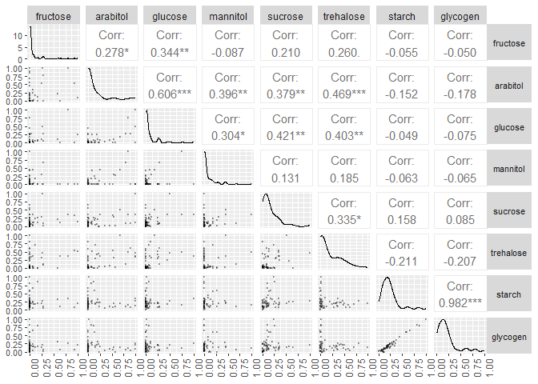

```r
#graph
output <- samples_pairwise_sugars_cconc %>%
  rename_with(~ substr(.x, 1, nchar(.x) - 8)) %>%
  ggpairs(progress = FALSE,
          lower = list(continuous = wrap("points", alpha = 0.3, size=0.2))) +
  theme(axis.text.x = element_text(angle = 90, hjust = 1, size = 9),
        axis.text.y = element_text(size = 8),
        strip.text.y = element_text(size = 8, angle = 0)
        )
print(output)
```

### 4.5.2 Sample Volume Correlated with c_conc?

The flush volume varies with each sample. Supposing there was a fixed amount of exudate on each sample before flushing, if the flush completely washed it off, we would expect the concentration of C measured to vary by the flush volume. Let’s check:

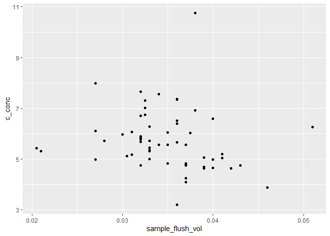

```r
## new table
samples_flush_c_conc <- samples %>%
  select(sample_id, sample_flush_vol, c_conc) %>%
  na.omit()

## graph
samples_flush_c_conc %>% ggplot(aes(x = sample_flush_vol, y = c_conc)) +
  geom_point()
```

###Boxplots of Controls vs Samples

```r
## Samples table
samples_c_conc_mg <- samples %>%
  select(sample_id, sample_flush_vol, c_conc) %>%
  na.omit() %>%
  mutate("c_conc_mg" = sample_flush_vol * c_conc) %>%
  mutate("type" = "samples") %>%
  rename(id = sample_id, flush_vol = sample_flush_vol)
samples_c_conc_mg # n = 59
```

```
## # A tibble: 59 × 5
##    id    flush_vol c_conc c_conc_mg type
##    <chr>     <dbl>  <dbl>     <dbl> <chr>
##  1 S001     0.037    4.82     0.178 samples
##  2 S002     0.038   10.8      0.408 samples
##  3 S003     0.0375   6.04     0.226 samples
##  4 S004     0.0205   5.43     0.111 samples
##  5 S005     0.032    5.77     0.185 samples
##  6 S006     0.037    4.74     0.175 samples
##  7 S007     0.027    4.97     0.134 samples
##  8 S008     0.033    5.00     0.165 samples
##  9 S009     0.032    4.74     0.152 samples
## 10 S010     0.039    5.07     0.198 samples
## # ℹ 49 more rows
```

```r
## controls table
controls_c_conc_mg <- controls %>%
  select(control_id, control_flush_vol, control_carbon_conc) %>%
  na.omit() %>%
  mutate("c_conc_mg" = control_flush_vol * control_carbon_conc) %>%
  mutate("type" = "controls") %>%
  rename(id = control_id, flush_vol = control_flush_vol, c_conc = control_carbon_conc )
controls_c_conc_mg
```

```
## # A tibble: 16 × 5
##    id    flush_vol c_conc c_conc_mg type
##    <chr>     <dbl>  <dbl>     <dbl> <chr>
##  1 C012     0.04     3.82     0.153 controls
##  2 C015     0.033    4.33     0.143 controls
##  3 C013     0.035    4.47     0.156 controls
##  4 C001     0.034    4.59     0.156 controls
##  5 C008     0.0385   4.71     0.181 controls
##  6 C007     0.0305   5.22     0.159 controls
##  7 C006     0.029    5.31     0.154 controls
##  8 C009     0.028    5.79     0.162 controls
##  9 C010     0.03     5.95     0.178 controls
## 10 C011     0.031    5.96     0.185 controls
## 11 C005     0.027    6.12     0.165 controls
## 12 C003     0.033    6.18     0.204 controls
## 13 C002     0.03     6.18     0.186 controls
## 14 C004     0.029    6.21     0.180 controls
## 15 C016     0.032    7.27     0.233 controls
## 16 C014     0.035    7.71     0.270 controls
```

```r
# Bind rows

c_conc_all <- bind_rows(controls_c_conc_mg, samples_c_conc_mg)
c_conc_all
```

```
## # A tibble: 75 × 5
##    id    flush_vol c_conc c_conc_mg type
##    <chr>     <dbl>  <dbl>     <dbl> <chr>
##  1 C012     0.04     3.82     0.153 controls
##  2 C015     0.033    4.33     0.143 controls
##  3 C013     0.035    4.47     0.156 controls
##  4 C001     0.034    4.59     0.156 controls
##  5 C008     0.0385   4.71     0.181 controls
##  6 C007     0.0305   5.22     0.159 controls
##  7 C006     0.029    5.31     0.154 controls
##  8 C009     0.028    5.79     0.162 controls
##  9 C010     0.03     5.95     0.178 controls
## 10 C011     0.031    5.96     0.185 controls
## # ℹ 65 more rows
```

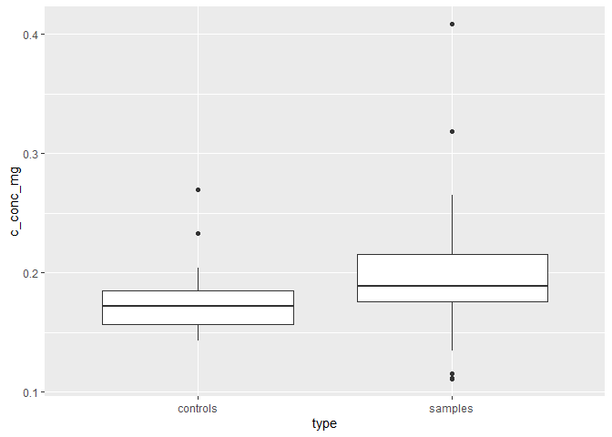

```r
# graph boxplots

c_conc_all %>%
  ggplot(aes(y = c_conc_mg, x = type)) +
    geom_boxplot()
```